# Data Visualization I

Activity 02

Author

Solutions

## Overview

The focus of Activity 02 will be on the basics of “The Grammar of Graphics” and scatterplots — our first of the five named graph (5NG).

## Needed Packages

The following loads the necessary packages for this activity. Also note that we have suppressed `message`s so the compiled html is less cluttered.

```r
library(nycflights13)
library(ggplot2)
library(dplyr)
```

## The Grammar of Graphics

“The Grammar of Graphics” define a set of rules for constructing statistical graphics by combining different types of **layers**. This is why you may hear it alternatively called the “The Layered Grammar of Graphics.”

### Helpful Tip

If you are ever unsure of how to use a function use the `?` followed by the function name to see a description of the function and useful examples. If you have not loaded the library with the function you will need to use `??` (ex: `?ggplot` or `??ggplot`).

## Tasks

Complete the following series of tasks. Remember to **render early and render often**.

## Task 1

### Alaska Flights dataset

Some datasets exist in packages while others are stored on your computer (in this case the Cloud) and accessed through the `data` folder.

The `flights` dataset is included in the `nycflights13` package. To learn more about the dataset you can type `?flights` in the **console** window.

Below is the code to create a dataset that contains only the 714 Alaska Airlines flights that left NYC in 2013. (We used filter to only include `AS` which is Alaska Airlines).

Run the code chunk below.

```r
alaska_flights <- flights %>%
  filter(carrier == "AS")
```

Now navigate to the `Environment` tab in the top right panel. Notice there is a new dataset created named `alaska_flights`. Click on it.

How many variables and how many observations does the dataset have?

**19 variables**

When defining aesthetics in a plot (ie: x, y, color, shape, size), they must be **variables** from the dataset you specify. To see the names of the possible variables you must explore your dataset.

### Alaska flights scatterplot

Below is the code that produced Figure 2.4 in the book.

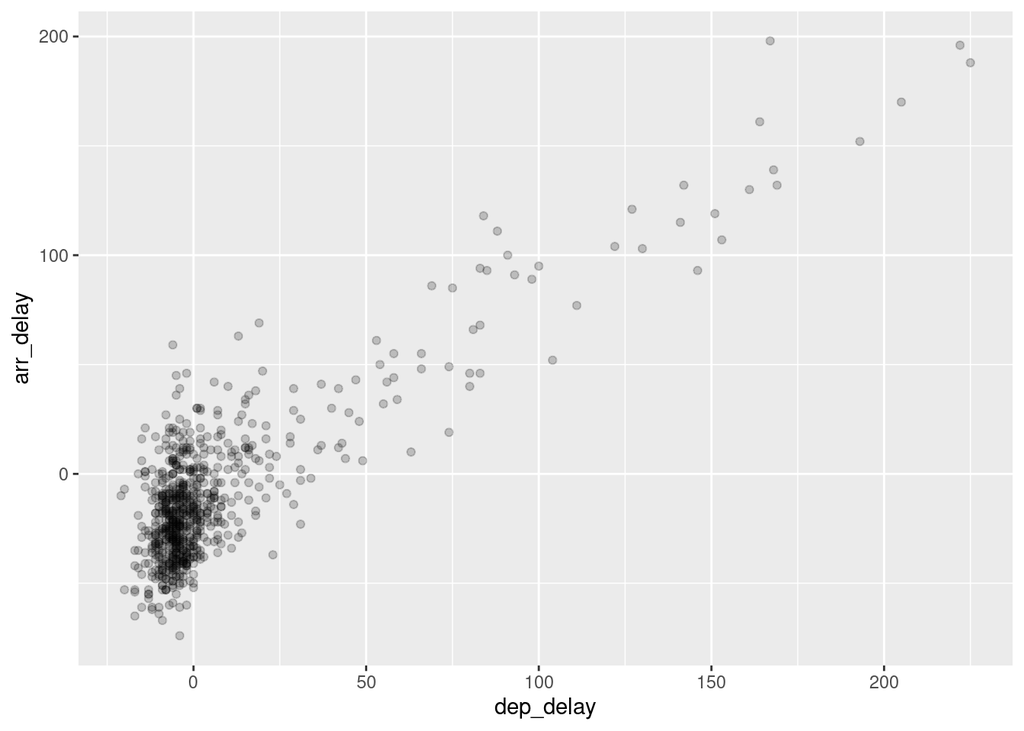

```r
ggplot(data = alaska_flights,
       mapping = aes(x = dep_delay, y = arr_delay)) +
  geom_point(alpha = 0.2)
```

What does `alpha = 0.2` do to the graph?

**It changes the transparency of the points to address overplotting issues. A value of 0 is 100% transparent and a value of 1 is 100% opaque.**

Describe what the scatterplot is communicating about these 714 Alaska Airlines flights that left NYC in 2013.

**There is a clear positive linear association between `arr_delay` and `dep_delay` for these flights. We also see that a significant portion (maybe majority) arrive early and depart on-time/early.**

## Task 2

### Miles per Gallon

Let’s explore the `mpg` dataset which is loaded with the `ggplot2` package. You can learn more about the `mpg` dataset by running `?mpg` in the console.

You can load the `mpg` dataset into your Environment pane by typing `data(mpg)` in the Console (not necessary but some students prefer to see their dataset there).

```r
# print the data
mpg
```

```
# A tibble: 234 × 11
   manufacturer model      displ  year   cyl trans drv     cty   hwy fl    class
   <chr>        <chr>      <dbl> <int> <int> <chr> <chr> <int> <int> <chr> <chr>
 1 audi         a4           1.8  1999     4 auto… f        18    29 p     comp…
 2 audi         a4           1.8  1999     4 manu… f        21    29 p     comp…
 3 audi         a4           2    2008     4 manu… f        20    31 p     comp…
 4 audi         a4           2    2008     4 auto… f        21    30 p     comp…
 5 audi         a4           2.8  1999     6 auto… f        16    26 p     comp…
 6 audi         a4           2.8  1999     6 manu… f        18    26 p     comp…
 7 audi         a4           3.1  2008     6 auto… f        18    27 p     comp…
 8 audi         a4 quattro   1.8  1999     4 manu… 4        18    26 p     comp…
 9 audi         a4 quattro   1.8  1999     4 auto… 4        16    25 p     comp…
10 audi         a4 quattro   2    2008     4 manu… 4        20    28 p     comp…
# … with 224 more rows
```

Below is a scatterplot of `hwy` (highway miles per gallon) by `cty` (city miles per gallon). What is wrong with the plot?

**Clear overplotting issues.**

Make the appropriate adjustment to the code (Hint: section 2.3.2).

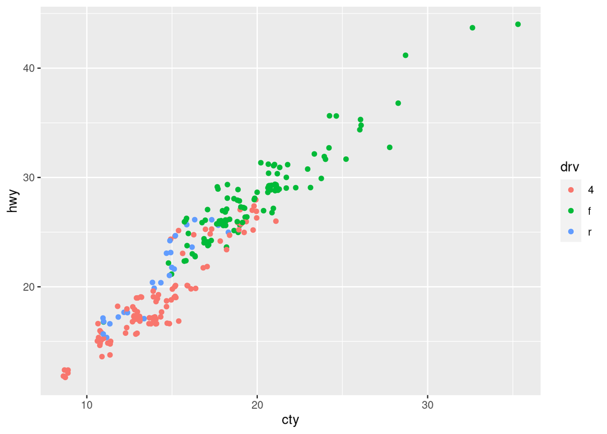

```r
ggplot(data = mpg, mapping = aes(x = cty, y = hwy)) +
  geom_jitter(aes(color = drv))
```

Additionally, map the variable `drv` to the `color` `aes`thetic of the points. Note that `drv` is a character variable. What are the possible drive types?

**f = front-wheel drive, r = rear wheel drive, 4 = 4wd**

In a few sentences describe what the scatterplot is communicating about the cars in the `mpg` dataset.

**There is a clear positive linear association between city (`cty`) and highway (`hwy`) miles per gallon. It appears that front-wheel drive vehicles generally have better gas mileage in this dataset.**

## Task 3

### Blue Jays

Let’s explore the `blue_jays` dataset which should be in your `data/` subdirectory. This dataset contains measurements on 123 blue jays. The code below loads the data from your data subdirectory, stores it in a more useful format, and then finally prints it for us to inspect.

```r
# Load data from file
load("data/blue_jays.rda")
# Store in a more useful format
blue_jays <- blue_jays %>%
  as_tibble()
# Print data
blue_jays
```

```
# A tibble: 123 × 9
   BirdID     KnownSex BillDepth BillWidth BillLength  Head  Mass Skull   Sex
   <fct>      <fct>        <dbl>     <dbl>      <dbl> <dbl> <dbl> <dbl> <int>
 1 0000-00000 M             8.26      9.21       25.9  56.6  73.3  30.7     1
 2 1142-05901 M             8.54      8.76       25.0  56.4  75.1  31.4     1
 3 1142-05905 M             8.39      8.78       26.1  57.3  70.2  31.2     1
 4 1142-05907 F             7.78      9.3        23.5  53.8  65.5  30.3     0
 5 1142-05909 M             8.71      9.84       25.5  57.3  74.9  31.8     1
 6 1142-05911 F             7.28      9.3        22.2  52.2  63.9  30       0
 7 1142-05912 M             8.74      9.28       25.4  57.1  75.1  31.8     1
 8 1142-05914 M             8.72      9.94       30    60.7  78.1  30.7     1
 9 1142-05917 F             8.2       9.01       22.8  52.8  64    30.0     0
10 1142-05920 F             7.67      9.31       24.6  54.9  67.3  30.3     0
# … with 113 more rows
```

Construct a scatterplot of `Head`, distance from tip of bill to back of head (in mm), by `Mass`, body mass (in grams). Also map the `KnownSex`, sex of the bird, to both the `color` and `shape` `aes`thetics.

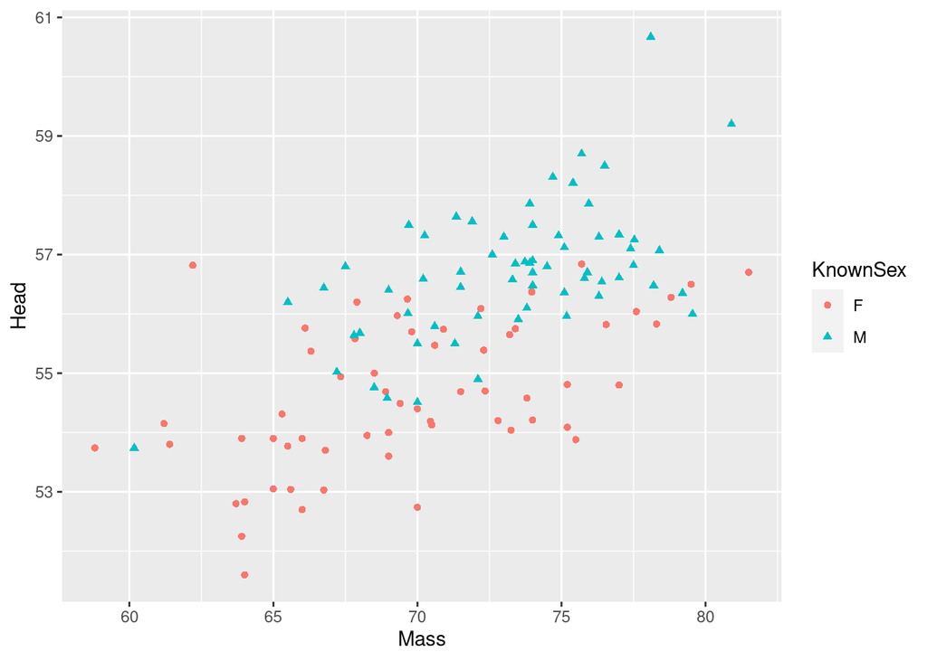

```r
# BUILD THE PLOT IN THIS CODE CHUNK
ggplot(data = blue_jays, mapping = aes(x = Mass, y = Head)) +
  geom_point(aes(color = KnownSex, shape = KnownSex))
```

In a few sentences describe what the scatterplot is communicating about the blue jays in our `blue_jays` dataset.

**There is a clear positive linear association between the distance from tip of bill to back of the head and body mass of blue jays in this dataset. It also appears that female blue jays in the dataset tend to smaller in both measurements.**

Why might we map a single variable to two aesthetics?

**To help people that are color blind.**

## Task 4

### Legosets

Let’s explore the `legosets` dataset which should be in your `data/` subdirectory. This dataset contains information about every Lego set manufactured from 1970 to 2015, a total of 6172 sets. The code below loads the data from your data subdirectory and creates to two separate datasets. One containing Duplo lego sets which are for toddlers/preschoolers and one containing all other lego sets which are for older kids. Finally we `glimpse` one of the datasets because both should have the same structure.

```r
# Load data from file
load("data/legosets.rda")
# Non-duplo (for big kids, like Professor Kuyper)
lego_nonduplo <- legosets %>%
  filter(Theme != "Duplo")
# Duplo (for young kids, toddlers)
lego_duplo <- legosets %>%
  filter(Theme == "Duplo")
# Check for variables
glimpse(lego_nonduplo)
```

```
Rows: 5,701
Columns: 14
$ Item_Number  <chr> "10246", "10247", "10248", "10249", "10677", "10679", "10…
$ Name         <chr> "Detective's Office", "Ferris Wheel", "Ferrari F40", "Toy…
$ Year         <int> 2015, 2015, 2015, 2015, 2015, 2015, 2015, 2015, 2015, 201…
$ Theme        <chr> "Advanced Models", "Advanced Models", "Advanced Models", …
$ Subtheme     <chr> "Modular Buildings", "Fairground", "Vehicles", "Winter Vi…
$ Pieces       <int> 2262, 2464, 1158, 898, 74, 57, 99, 132, 134, 113, 226, 13…
$ Minifigures  <int> 6, 10, NA, NA, 1, 2, 2, 2, 2, 2, 3, NA, NA, NA, NA, NA, N…
$ Image_URL    <chr> "http://images.brickset.com/sets/images/10246-1.jpg", "ht…
$ GBP_MSRP     <dbl> 132.99, 149.99, 69.99, 59.99, 9.99, 9.99, 15.99, 15.99, 1…
$ USD_MSRP     <dbl> 159.99, 199.99, 99.99, 79.99, 9.99, 9.99, 19.99, 19.99, 1…
$ CAD_MSRP     <dbl> 199.99, 229.99, 119.99, NA, 12.99, 12.99, 24.99, 24.99, 2…
$ EUR_MSRP     <dbl> 149.99, 179.99, 89.99, 69.99, 9.99, 9.99, 19.99, 19.99, 2…
$ Packaging    <chr> "Box", "Box", "Box", "Box", "Box", "Box", "Box", "Box", "…
$ Availability <chr> "Retail - limited", "Retail - limited", "LEGO exclusive",…
```

There are only a few real candidates for constructing a scatterplot. You should be able to identify them quickly. It might be useful to know that **MSRP** stands for **M**anufacturer’s **S**uggested **R**etail **P**rice.

Using the `lego_nonduplo` dataset, construct a scatterplot of `USD_MSRP`, a set’s MSRP in US dollars, by `Pieces`, the number of pieces in a set.

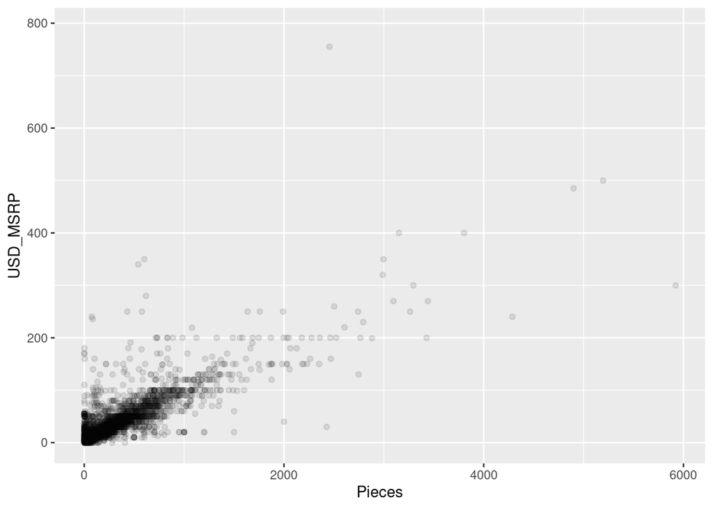

```r
ggplot(data = lego_nonduplo, mapping = aes(x = Pieces, y = USD_MSRP)) +
  geom_point(alpha = 0.1)
```

Does the relationship you observe in the scatterplot make sense? Explain.

**Yes, it does make sense. We see a positive association which means that the more pieces a lego set contains the greater its price.**

## Optional Challenges

**Do not have to complete.**

### Challenge 1

It is often useful to “add” another `geom`etric layer when exploring data with scatterplots. This additional layer helps us to detect and describe relationships. All we have to do is add `geom_smooth(se = FALSE)`.

Copy and paste the code for one of the completed scatterplots above and simply layer on `geom_smooth(se = FALSE)` by “adding” it to the code.

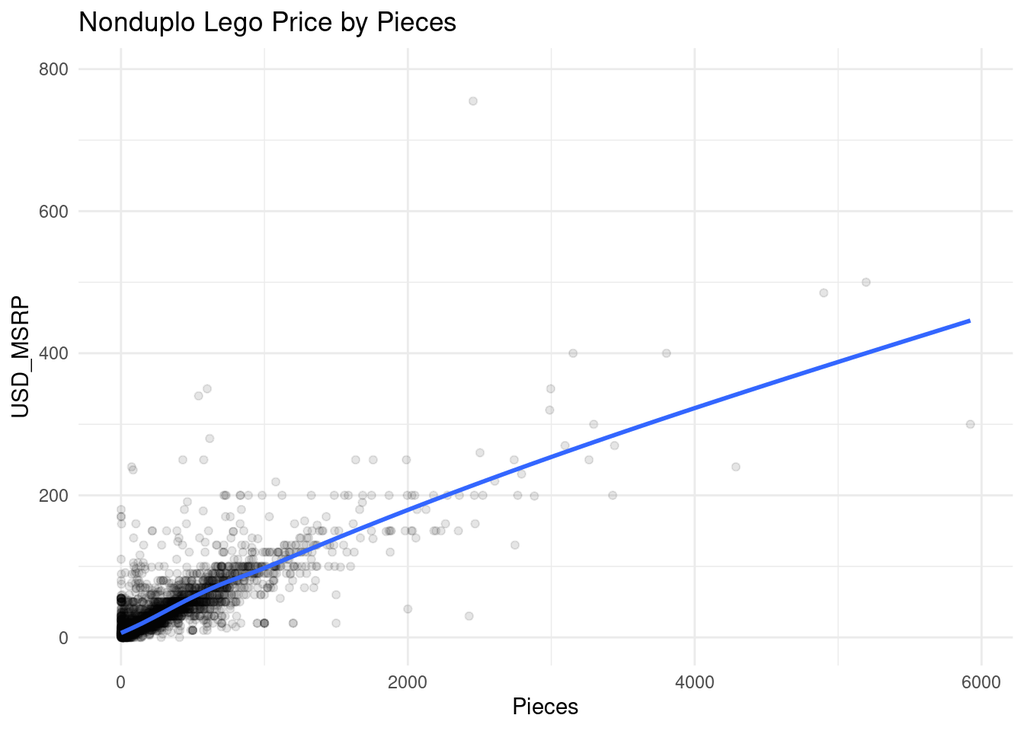

```r
ggplot(data = lego_nonduplo, mapping = aes(x = Pieces, y = USD_MSRP)) +
  geom_point(alpha = 0.1) +
  geom_smooth(se = FALSE) +
  labs(title = "Nonduplo Lego Price by Pieces") +
  theme_minimal()
```

### Challenge 2

With an additional layer or two you can make your plot look a lot prettier. Add a title to your plot in the above ‘Challenge 1’ by “adding” on the layer `labs(title = "Your title")`. Where “Your title” is an appropriate title for your plot.

Then “add” on the layer `theme_minimal()` to make the background and display more visually appealing.